# Final Project 204881403-204865687

### GSEA-

Now, instead of looking at specific genes, we want to look at pathways that are differentially expressed overall. We will do this with Gene Set Enrichment Analysis.

```r
resOrdered.nona <- resOrdered_BEC[!is.na(resOrdered_BEC$padj),]
genes_ordered <- sort(resOrdered.nona$log2FoldChange, decreasing = T)
```

- We now need to get the Hallmarks pathways gene sets using the msigdbr package:

```r
hallmarks <- msigdbr(species = "Homo sapiens", category = "H") %>%
  dplyr::select(gs_name, gene_symbol)
```

```r
hm <-GSEA(genes_ordered, TERM2GENE = hallmarks)
```

```
## preparing geneSet collections...
```

```
## GSEA analysis...
```

```
## leading edge analysis...
```

```
## done...
```

- Finally, we visualize the results of this analysis using the dotPlot function:

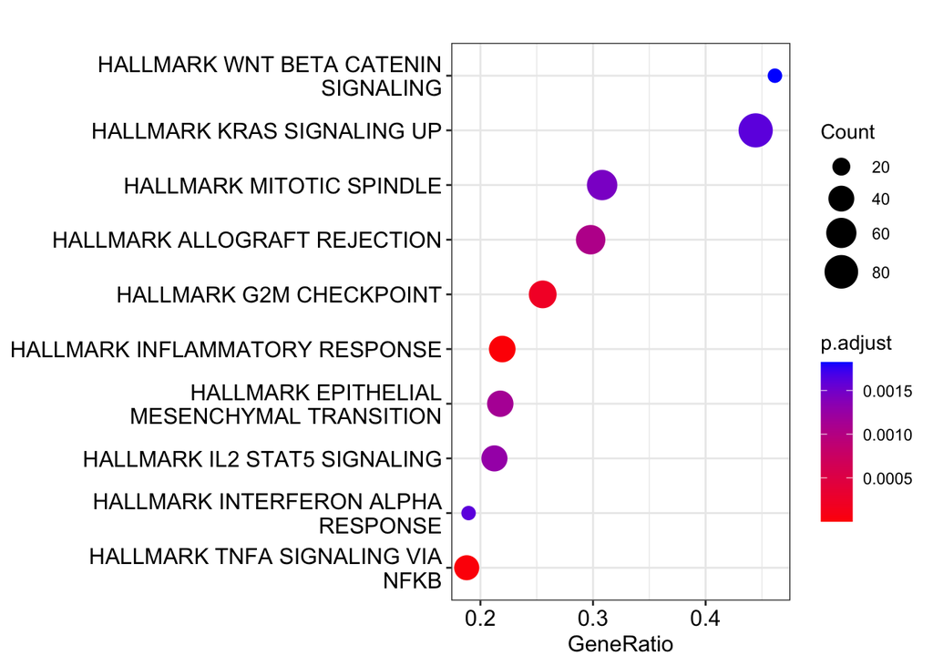

```r
hallmarks <- msigdbr(species = "Homo sapiens", category = "H")
hallmarks <- hallmarks[,c('gs_name', 'gene_symbol')]

dotplot(hm)
```

Beta Catenin – Homeostasis, cell proliferation, inflammation-associated cancer  
Kras Signaling – Cell division, differentiation, apoptosis  
Mitotic spindle – Cell division  
Allograft rejection – Transplant rejection  
G2M checkpoint- Cell proliferation  
Inflammatory response  
Epithelial Mesenchymal Transition – Wound healing  
Il2 Stat5 Signaling – Immune function  
Interferon alpha response – Contributes to apoptosis and drug resistance  
TNFA signaling – Cell cycle regulation

These are some of the same pathways that were identified in the Camiolo study from which we took our data <sup>(1)</sup>.

## SECOND ANALYSIS: GWAS -

Here, we used two sets of summary statistics. One was from a study of patients with adult onset asthma, and the other of patients with Childhood onset asthma. These two datasets include people of European Descent and use the same set of controls in order to reduce the number of SNPs that are unrelated to the disease. We will make a manhattan plot from each set of statistics:

```r
data_adult = read.table("ADULT1_ADULT2_ONSET_ASTHMA.20180716.allchr.assoc.GC.gz", header = TRUE)
head(data_adult)
```

```
##          SNP CHR        BP ALLELE1 ALLELE0    A1FREQ     INFO     BETA
## 1       rs10   7  92383888       A       C 0.0584583 0.939077 1.006670
## 2    rs10000   7   6013153       A       G 0.8840220 0.602281 1.004020
## 3  rs1000000  12 126890980       G       A 0.7743960 0.999152 0.984237
## 4 rs10000000   4  40088896       A       T 0.9475050 0.982306 1.023600
## 5 rs10000003   4  57561647       A       G 0.2984920 0.997534 0.985656
## 6 rs10000005   4  85161558       G       A 0.4655290 0.994261 0.978775
##           SE P_BOLT_LMM_INF      N    SE_GC    P_GC
## 1 0.01825810           0.72 327253 0.018421 0.71820
## 2 0.01672560           0.81 327253 0.016875 0.81210
## 3 0.00994918           0.11 327253 0.010038 0.11350
## 4 0.01883920           0.22 327253 0.019007 0.21970
## 5 0.00910150           0.11 327253 0.009183 0.11560
## 6 0.00834308           0.01 327253 0.008417 0.01081
```

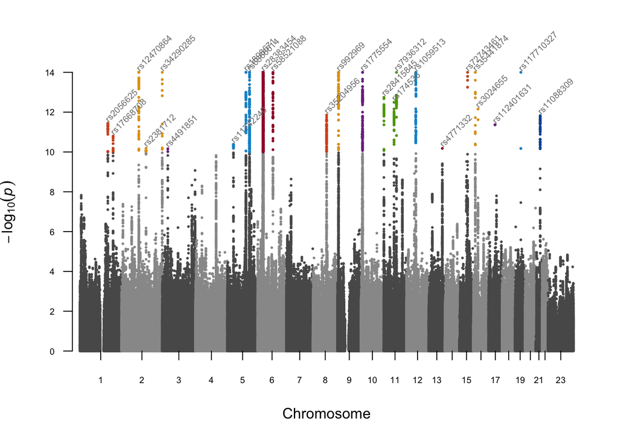

```r
fastman(data_adult, chr="CHR", bp = "BP", p="P_BOLT_LMM_INF", snp = "SNP", annotatePval = 1E-10, annotationWinMb = 6, colAbovePval = TRUE,genomewideline = FALSE, suggestiveline=FALSE,cex.text=0.6,speedup=TRUE)
```

```r
data_2 = read.table("CHILD_ONSET_ASTHMA.20180501.allchr.assoc.GC.gz", header = TRUE)
head(data_2)
```

```
##          SNP CHR        BP ALLELE1 ALLELE0    A1FREQ     INFO     BETA
## 1       rs10   7  92383888       A       C 0.0584995 0.939077 1.032800
## 2    rs10000   7   6013153       A       G 0.8840830 0.602281 1.028410
## 3  rs1000000  12 126890980       G       A 0.7743830 0.999152 0.969239
## 4 rs10000000   4  40088896       A       T 0.9473580 0.982306 0.976249
## 5 rs10000003   4  57561647       A       G 0.2987900 0.997534 1.003380
## 6 rs10000005   4  85161558       G       A 0.4657850 0.994261 0.989322
##          SE P_BOLT_LMM_INF      N    SE_GC    P_GC
## 1 0.0253682          0.200 314633 0.025858 0.21200
## 2 0.0232648          0.230 314633 0.023714 0.23750
## 3 0.0138248          0.024 314633 0.014092 0.02661
## 4 0.0261471          0.360 314633 0.026652 0.36710
## 5 0.0126425          0.790 314633 0.012887 0.79340
## 6 0.0115956          0.350 314633 0.011820 0.36380
```

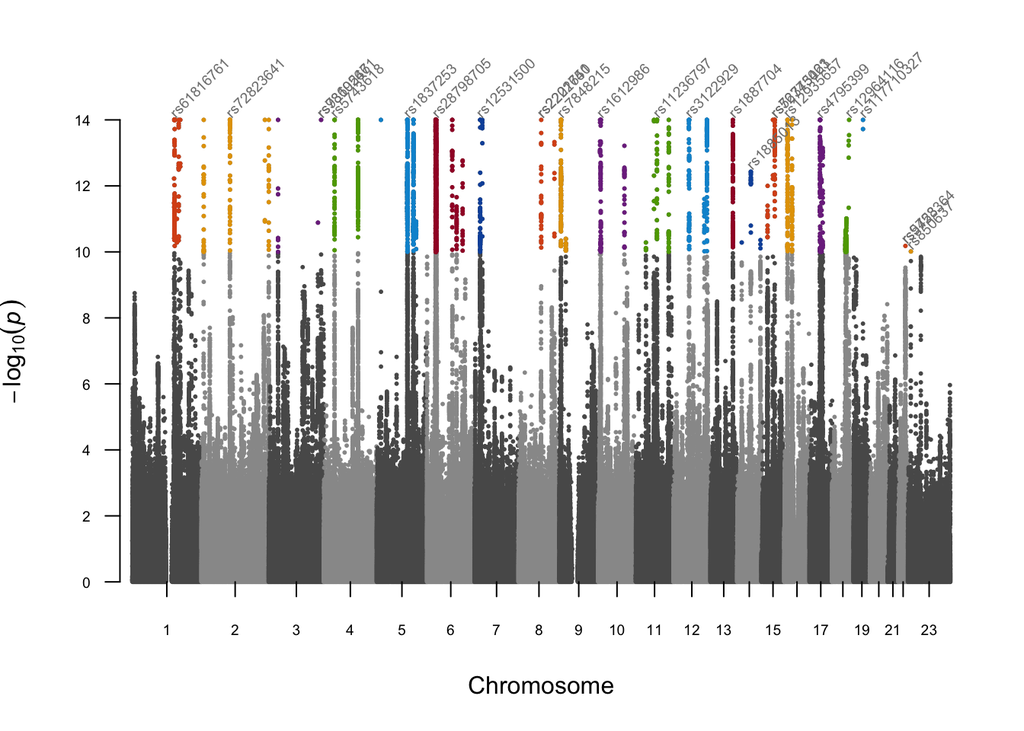

```r
fastman(data_2, chr="CHR", bp = "BP", p="P_BOLT_LMM_INF", snp = "SNP", annotatePval = 1E-10, colAbovePval = TRUE,genomewideline = FALSE, suggestiveline=FALSE,cex.text = 0.6,speedup=TRUE)
```

We can see from each plot that there are very many significant SNPs, especially in the childhood onset asthma plot. Thus, this GWAS analysis does not give us a single distinct SNP that is associated with age of onset. However, upon comparing the SNPs and their associated genes, we did find that these results match the results from the study from which we took the data. We correctly identified many of the same SNPs as the Ferreira study<sup>(2)</sup>.

This suggests that there is some genetic difference between those with Childhood Onset Asthma and those with Adult Onset Asthma - there are a few SNPS that are more common in AOA than COA and vice versa. This could present an opportunity to predict asthma onset in different patients and also targets for potential therapies.

#### Works Cited:

1. Camiolo MJ, Zhou X, Oriss TB, et al. High-dimensional profiling clusters asthma severity by lymphoid and non-lymphoid status. Cell Rep. 2021;35(2):108974. doi:10.1016/j.celrep.2021.108974
2. Ferreira MAR, Mathur R, Vonk JM, et al. Genetic architectures of childhood- and adult-onset asthma are partly distinct. Am J Hum Genet. 2019;104(4):665-684. doi:10.1016/j.ajhg.2019.02.022